# Prospective Power Analysis Beyond the Web App

### Read saturation Curve Visualization

From the library_params in the pilot data, let’s first visualize the relationship between reads per cell and UMIs per cell, and see how the experimental designs in Section 2 map onto the curve:

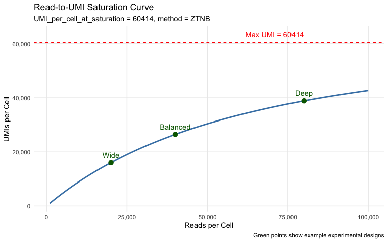

```r
# Extract library parameters
UMI_max <- library_params$UMI_per_cell_at_saturation

# Generate saturation curve using fit_read_UMI_curve_cpp
reads_range <- seq(1000, 100000, length.out = 200)
umis_predicted <- fit_read_UMI_curve_cpp(reads_range, library_params)

saturation_df <- data.frame(
  Reads_per_Cell = reads_range,
  UMIs_per_Cell = umis_predicted,
  Saturation_Pct = (umis_predicted / UMI_max) * 100
)

# Plot saturation curve
ggplot(saturation_df, aes(x = Reads_per_Cell, y = UMIs_per_Cell)) +
  geom_line(linewidth = 1, color = "steelblue") +
  geom_hline(yintercept = UMI_max, linetype = "dashed", color = "red") +
  annotate("text", x = 80000, y = UMI_max * 1.05,
           label = sprintf("Max UMI = %d", round(UMI_max)),
           color = "red", hjust = 1) +
  # Add example design points
  geom_point(data = data.frame(
    Reads_per_Cell = c(20000, 40000, 80000),
    Design = c("Wide", "Balanced", "Deep")
  ), aes(x = Reads_per_Cell, y = fit_read_UMI_curve_cpp(c(20000, 40000, 80000), library_params)),
  size = 3, color = "darkgreen") +
  geom_text(data = data.frame(
    Reads_per_Cell = c(20000, 40000, 80000),
    Design = c("Wide", "Balanced", "Deep"),
    UMI = fit_read_UMI_curve_cpp(c(20000, 40000, 80000), library_params)
  ), aes(x = Reads_per_Cell, y = UMI, label = Design),
  vjust = -1, color = "darkgreen") +
  scale_x_continuous(labels = scales::comma) +
  scale_y_continuous(labels = scales::comma) +
  labs(
    title = "Read-to-UMI Saturation Curve",
    subtitle = sprintf("UMI_per_cell_at_saturation = %d, method = %s",
                      round(UMI_max), library_params$method_used),
    x = "Reads per Cell",
    y = "UMIs per Cell",
    caption = "Green points show example experimental designs"
  ) +
  theme_minimal() +
  theme(panel.grid.minor = element_blank())
```

Also, we can visualize how the percentage of UMI detected (saturation) increases with read depth:

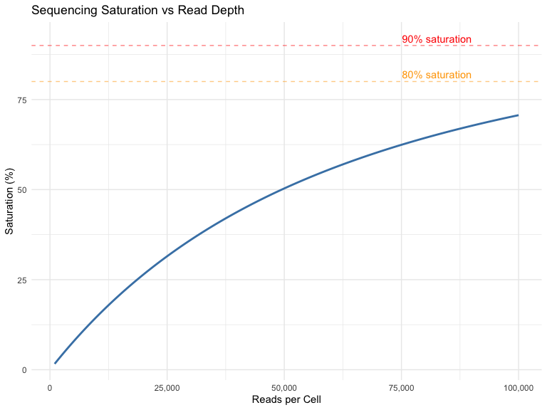

```r
# Saturation percentage vs reads
ggplot(saturation_df, aes(x = Reads_per_Cell, y = Saturation_Pct)) +
  geom_line(linewidth = 1, color = "steelblue") +
  geom_hline(yintercept = 80, linetype = "dashed", color = "orange", alpha = 0.5) +
  geom_hline(yintercept = 90, linetype = "dashed", color = "red", alpha = 0.5) +
  annotate("text", x = 90000, y = 82, label = "80% saturation",
           color = "orange", hjust = 1) +
  annotate("text", x = 90000, y = 92, label = "90% saturation",
           color = "red", hjust = 1) +
  scale_x_continuous(labels = scales::comma) +
  labs(
    title = "Sequencing Saturation vs Read Depth",
    x = "Reads per Cell",
    y = "Saturation (%)"
  ) +
  theme_minimal()
```

## See Also

- `?compute_power_plan`: Prospective power analysis for experimental planning
- `?compute_power_plan_per_grid`: Grid-based power analysis
- `?library_estimation`: Library parameter estimation from QC data
- Vignette “Preprocess Reference Expression Data”: Creating custom pilot data
- Vignette “Getting Started with PerturbPlan”: Basic power analysis workflow